# Simulate data with Jags

Olivier Gimenez, November 21 2017

## Motivation

Recently, I have been struggling with simulating data from complex hierarchical models. After several unsuccessful attempts in `R`, I remembered the good old times when I was using `WinBUGS` (more than 10 years already!) and the possibility to simulate data with it. I’m using `Jags` now, and a quick search in Google with ‘simulating data with jags’ led me to [a complex example](https://www.georg-hosoya.de/wordpress/?p=799) and [a simple example](https://stackoverflow.com/questions/38295839/simulate-data-in-jags-r2jags).

Here, I illustrate the possibility to use Jags to simulate data with two examples that might be of interest to population ecologists: first a linear regression, second a Cormack-Jolly-Seber capture-recapture model to estimate animal survival (formulated as a state-space model).

Simulating data with `Jags` is convenient because you can use (almost) the same code for simulation and inference, and you can carry out simulation studies (bias, precision, interval coverage) in the same environment (namely `Jags`).

## Linear regression example

We first load the packages we will need for this tutorial:

```r
library(R2jags)
library(runjags)
library(mcmcplots)
```

Then straight to the point, let’s generate data from a linear regression model. The trick is to use a `data` block, have the simplest `model` block you could think of and pass the parameters as if they were data. Note that it’d be possible to use only a model block, see comment [here](https://stackoverflow.com/questions/38295839/simulate-data-in-jags-r2jags).

```r
txtstring <- '
data{
# Likelihood:
for (i in 1:N){
y[i] ~ dnorm(mu[i], tau) # tau is precision (1 / variance)
mu[i] <- alpha + beta * x[i]
}
}
model{
fake <- 0
}
'
```

Here, `alpha` and `beta` are the intercept and slope, `tau` the precision or the inverse of the variance, `y` the response variable and `x` the explanatory variable.

We pick some values for the model parameters that we will use as data:

```r
# parameters for simulations
N = 30 # nb of observations
x <- 1:N # predictor
alpha = 0.5 # intercept
beta = 1 # slope
sigma <- .1 # residual sd
tau <- 1/(sigma*sigma) # precision
# parameters are treated as data for the simulation step
data<-list(N=N,x=x,alpha=alpha,beta=beta,tau=tau)
```

Now call jags; note that we monitor the response variable instead of parameters as we would do when conducting standard inference:

```r
# run jags
out <- run.jags(txtstring, data = data,monitor=c("y"),sample=1, n.chains=1, summarise=FALSE)
```

```
## Compiling rjags model...
## Calling the simulation using the rjags method...
## Note: the model did not require adaptation
## Burning in the model for 4000 iterations...
## Running the model for 1 iterations...
## Simulation complete
## Finished running the simulation
```

The output is a bit messy and needs to be formated appropriately:

```r
# reformat the outputs
Simulated <- coda::as.mcmc(out)
Simulated
```

```
## Markov Chain Monte Carlo (MCMC) output:
## Start = 5001
## End = 5001
## Thinning interval = 1
##         y[1]     y[2]     y[3]     y[4]     y[5]     y[6]     y[7]
## 5001 1.45689 2.486366 3.412447 4.533396 5.453686 6.352531 7.395596
##          y[8]     y[9]   y[10]    y[11]    y[12]    y[13]    y[14]
## 5001 8.548135 9.456741 10.4527 11.44249 12.45174 13.41898 14.44687
##         y[15]    y[16]    y[17]    y[18]    y[19]    y[20]    y[21]
## 5001 15.50512 16.47502 17.54308 18.42312 19.48457 20.64009 21.48312
##         y[22]    y[23]    y[24]    y[25]    y[26]   y[27]    y[28]
## 5001 22.49401 23.50201 24.50974 25.45172 26.47198 27.5872 28.41214
##         y[29]    y[30]
## 5001 29.49843 30.57353
```

```r
dim(Simulated)
```

```
## [1]  1 30
```

```r
dat = as.vector(Simulated)
dat
```

```
##  [1]  1.456890  2.486366  3.412447  4.533396  5.453686  6.352531  7.395596
##  [8]  8.548135  9.456741 10.452698 11.442488 12.451736 13.418977 14.446869
## [15] 15.505122 16.475024 17.543081 18.423118 19.484566 20.640086 21.483117
## [22] 22.494013 23.502012 24.509736 25.451719 26.471981 27.587203 28.412137
## [29] 29.498432 30.573526
```

Now let’s fit the model we used to simulate to the data we just generated. I won’t go into the details and assume that the reader is familiar with `Jags` and linear regression.

```r
# specify model in BUGS language
model <-
paste("
model {
# Likelihood:
for (i in 1:N){
y[i] ~ dnorm(mu[i], tau) # tau is precision (1 / variance)
mu[i] <- alpha + beta * x[i]
}
# Priors:
alpha ~ dnorm(0, 0.01) # intercept
beta ~ dnorm(0, 0.01) # slope
sigma ~ dunif(0, 100) # standard deviation
tau <- 1 / (sigma * sigma)
}
")
writeLines(model,"lin_reg.jags")

# data
jags.data <- list(y = dat, N = length(dat), x = x)

# initial values
inits <- function(){list(alpha = rnorm(1), beta = rnorm(1), sigma = runif(1,0,10))}

# parameters monitored
parameters <- c("alpha", "beta", "sigma")

# MCMC settings
ni <- 10000
nt <- 6
nb <- 5000
nc <- 2

# call JAGS from R
res <- jags(jags.data, inits, parameters, "lin_reg.jags", n.chains = nc, n.thin = nt, n.iter = ni, n.burnin = nb, working.directory = getwd())
```

```
## module glm loaded
```

Let’s have a look to the results and compare with the parameters we used to simulate the data (see above):

```r
# summarize posteriors
print(res, digits = 3)
```

```
## Inference for Bugs model at "lin_reg.jags", fit using jags,
##  2 chains, each with 10000 iterations (first 5000 discarded), n.thin = 6
##  n.sims = 1668 iterations saved
##          mu.vect sd.vect    2.5%     25%     50%     75%   97.5%  Rhat
## alpha      0.438   0.023   0.394   0.424   0.438   0.455   0.481 1.001
## beta       1.003   0.001   1.000   1.002   1.003   1.003   1.005 1.001
## sigma      0.060   0.008   0.046   0.054   0.059   0.064   0.078 1.000
## deviance -85.506   2.651 -88.518 -87.440 -86.197 -84.305 -78.674 1.001
##          n.eff
## alpha     1700
## beta      1700
## sigma     1700
## deviance  1700
##
## For each parameter, n.eff is a crude measure of effective sample size,
## and Rhat is the potential scale reduction factor (at convergence, Rhat=1).
##
## DIC info (using the rule, pD = var(deviance)/2)
## pD = 3.5 and DIC = -82.0
## DIC is an estimate of expected predictive error (lower deviance is better).
```

Pretty close!

Check convergence:

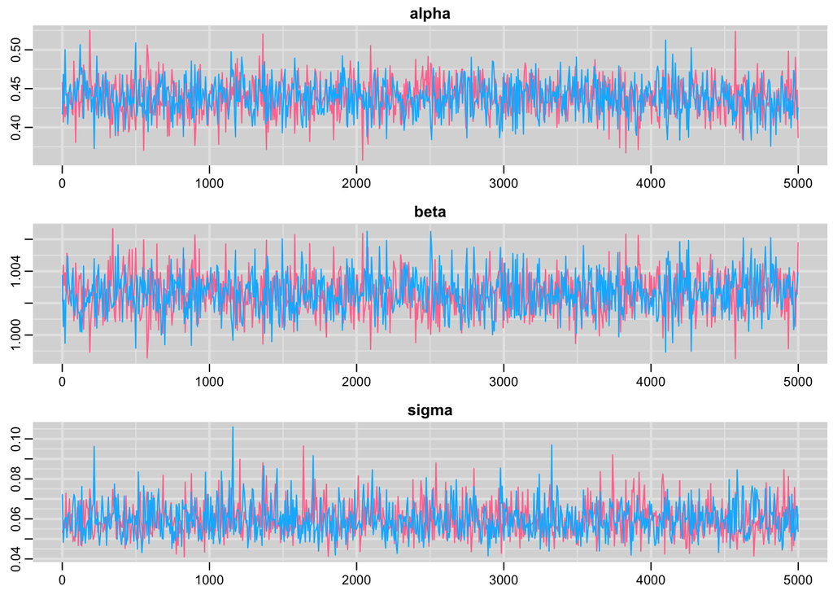

```r
# trace plots
traplot(res,c("alpha", "beta", "sigma"))
```

Plot the posterior distribution of the regression parameters and residual standard deviation:

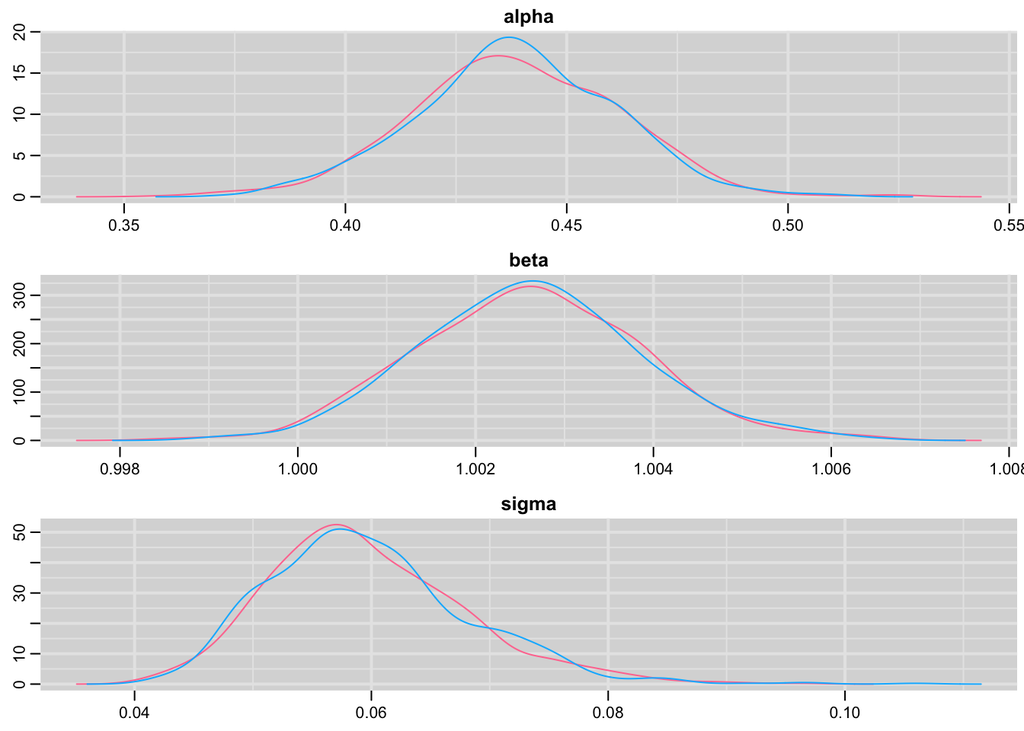

```r
# posterior distributions
denplot(res,c("alpha", "beta", "sigma"))
```

## Capture-recapture example

I now illustrate the use of `Jags` to simulate data from a Cormack-Jolly-Seber model with constant survival and recapture probabilities. I assume that the reader is familiar with this model and its formulation as a state-space model.

Let’s simulate!

```r
txtstring <- '
data{
# Constant survival and recapture probabilities
for (i in 1:nind){
   for (t in f[i]:(n.occasions-1)){
      phi[i,t] <- mean.phi
      p[i,t] <- mean.p
      } #t
   } #i
# Likelihood
for (i in 1:nind){
   # Define latent state and obs at first capture
   z[i,f[i]] <- 1
   mu2[i,1] <- 1 * z[i,f[i]] # detection is 1 at first capture ("conditional on first capture")
   y[i,1] ~ dbern(mu2[i,1])
   # then deal w/ subsequent occasions
   for (t in (f[i]+1):n.occasions){
      # State process
      z[i,t] ~ dbern(mu1[i,t])
      mu1[i,t] <- phi[i,t-1] * z[i,t-1]
      # Observation process
      y[i,t] ~ dbern(mu2[i,t])
      mu2[i,t] <- p[i,t-1] * z[i,t]
      } #t
   } #i
}
model{
fake <- 0
}
'
```

Let’s pick some values for parameters and store them in a data list:

```r
# parameter for simulations
n.occasions = 10 # nb of occasions
nind = 100 # nb of individuals
mean.phi <- 0.8 # survival
mean.p <- 0.6 # recapture
f = rep(1,nind) # date of first capture
data<-list(n.occasions = n.occasions, mean.phi = mean.phi, mean.p = mean.p, f = f, nind = nind)
```

Now run `Jags`:

```r
out <- run.jags(txtstring, data = data,monitor=c("y"),sample=1, n.chains=1, summarise=FALSE)
```

```
## Compiling rjags model...
## Calling the simulation using the rjags method...
## Note: the model did not require adaptation
## Burning in the model for 4000 iterations...
## Running the model for 1 iterations...
## Simulation complete
## Finished running the simulation
```

Format the output:

```r
Simulated <- coda::as.mcmc(out)
dim(Simulated)
```

```
## [1]    1 1000
```

```r
dat = matrix(Simulated,nrow=nind)
head(dat)
```

```
##      [,1] [,2] [,3] [,4] [,5] [,6] [,7] [,8] [,9] [,10]
## [1,]    1    1    0    0    0    0    0    0    0     0
## [2,]    1    1    0    0    0    0    0    0    0     0
## [3,]    1    1    0    1    0    1    0    1    1     1
## [4,]    1    0    1    0    1    0    0    0    0     0
## [5,]    1    0    0    0    0    0    0    0    0     0
## [6,]    1    0    0    0    0    0    0    0    0     0
```

Now we fit a Cormack-Jolly-Seber model to the data we’ve just simulated, assuming constant parameters:

```r
model <-
paste("
model {
# Priors and constraints
for (i in 1:nind){
   for (t in f[i]:(n.occasions-1)){
      phi[i,t] <- mean.phi
      p[i,t] <- mean.p
      } #t
   } #i
mean.phi ~ dunif(0, 1)         # Prior for mean survival
mean.p ~ dunif(0, 1)           # Prior for mean recapture
# Likelihood
for (i in 1:nind){
   # Define latent state at first capture
   z[i,f[i]] <- 1
   for (t in (f[i]+1):n.occasions){
      # State process
      z[i,t] ~ dbern(mu1[i,t])
      mu1[i,t] <- phi[i,t-1] * z[i,t-1]
      # Observation process
      y[i,t] ~ dbern(mu2[i,t])
      mu2[i,t] <- p[i,t-1] * z[i,t]
      } #t
   } #i
}
")
writeLines(model,"cjs.jags")
```

Prepare the data:

```r
# vector with occasion of marking
get.first <- function(x) min(which(x!=0))
f <- apply(dat, 1, get.first)
# data
jags.data <- list(y = dat, f = f, nind = dim(dat)[1], n.occasions = dim(dat)[2])
```

```r
# Initial values
known.state.cjs <- function(ch){
   state <- ch
   for (i in 1:dim(ch)[1]){
      n1 <- min(which(ch[i,]==1))
      n2 <- max(which(ch[i,]==1))
      state[i,n1:n2] <- 1
      state[i,n1] <- NA
      }
   state[state==0] <- NA
   return(state)
   }
inits <- function(){list(mean.phi = runif(1, 0, 1), mean.p = runif(1, 0, 1), z = known.state.cjs(dat))}
```

We’d like to carry out inference about survival and recapture probabilities:

```r
parameters <- c("mean.phi", "mean.p")
```

Standard MCMC settings:

```r
ni <- 10000
nt <- 6
nb <- 5000
nc <- 2
```

Ready to run `Jags`!

```r
# Call JAGS from R (BRT 1 min)
cjs <- jags(jags.data, inits, parameters, "cjs.jags", n.chains = nc, n.thin = nt, n.iter = ni, n.burnin = nb, working.directory = getwd())
```

Summarize posteriors and compare to the values we used to simulate the data:

```r
print(cjs, digits = 3)
```

```
## Inference for Bugs model at "cjs.jags", fit using jags,
##  2 chains, each with 10000 iterations (first 5000 discarded), n.thin = 6
##  n.sims = 1668 iterations saved
##          mu.vect sd.vect    2.5%     25%     50%     75%   97.5%  Rhat
## mean.p     0.588   0.032   0.524   0.565   0.589   0.611   0.650 1.001
## mean.phi   0.795   0.021   0.752   0.782   0.795   0.809   0.837 1.002
## deviance 467.714  19.456 431.305 454.215 466.848 479.965 507.506 1.000
##          n.eff
## mean.p    1700
## mean.phi   910
## deviance  1700
##
## For each parameter, n.eff is a crude measure of effective sample size,
## and Rhat is the potential scale reduction factor (at convergence, Rhat=1).
##
## DIC info (using the rule, pD = var(deviance)/2)
## pD = 189.4 and DIC = 657.1
## DIC is an estimate of expected predictive error (lower deviance is better).
```

Again pretty close!

Trace plots

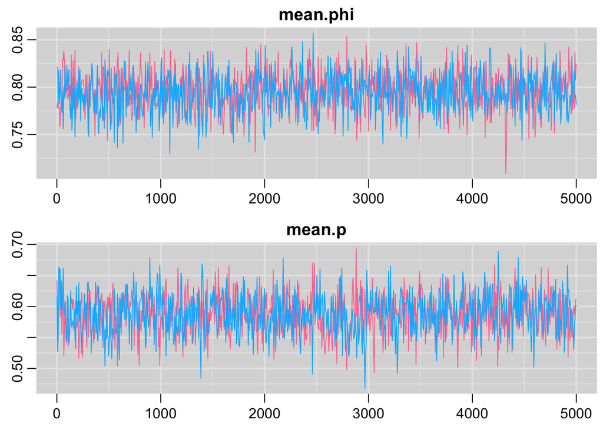

```r
traplot(cjs,c("mean.phi", "mean.p"))
```

Posterior distribution plots:

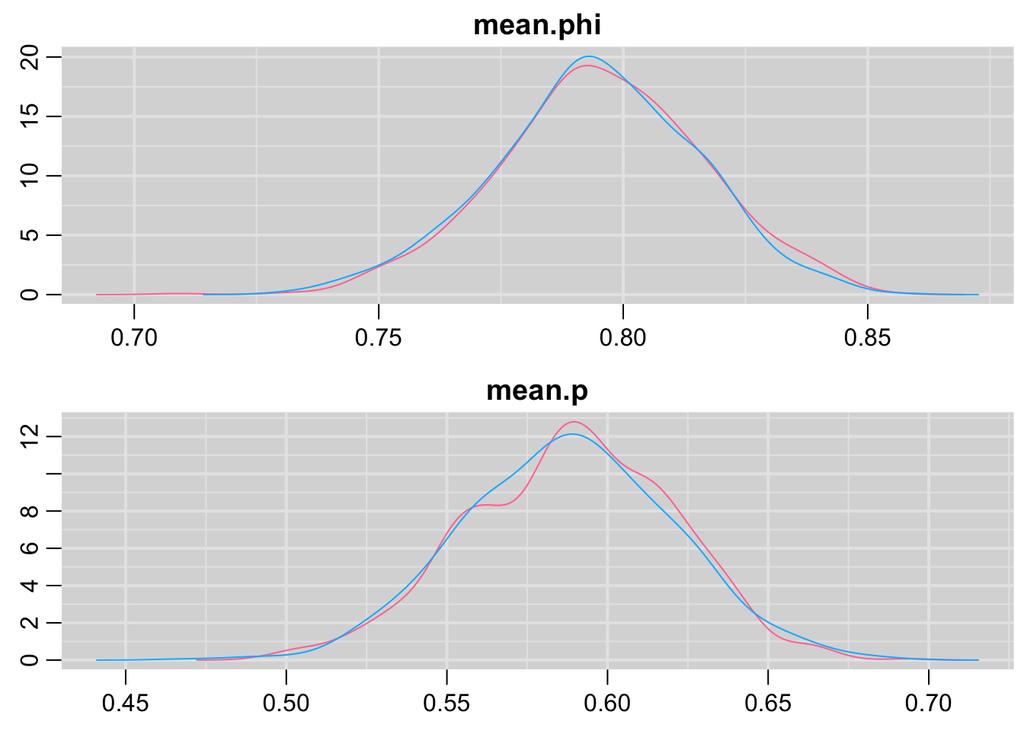

```r
denplot(cjs,c("mean.phi", "mean.p"))
```